# Project: Investigate of Tmdb movies Dataset

- Introduction
- Data Wrangling
- Exploratory Data Analysis
- Conclusions

## Introduction

Tmdb dataset contains 10866 rows and 21 columns which are `'id', 'imdb_id', 'popularity', 'budget', 'revenue', 'original_title', 'cast', 'homepage', 'director', 'tagline', 'keywords', 'overview', 'runtime', 'genres', 'production_companies', 'release_date', 'vote_count', 'vote_average', 'release_year', 'budget_adj', 'revenue_adj'`.

the dataset contains a valiable info about the popularity, the generes, the budget, revenue and the release year and date of each movie which is what we're gonna fouces on in this Notebook.

```python
# Use this cell to set up import statements for all of the packages that you
#   plan to use.
import pandas as pd
import matplotlib.pyplot as plt
import seaborn as sns
import numpy as np
%matplotlib inline
# Remember to include a 'magic word' so that your visualizations are plotted
#   inline with the notebook. See this page for more:
#   http://ipython.readthedocs.io/en/stable/interactive/magics.html
```

## Data Wrangling

### > General Properties

- let's load the dataset
- see how many rows and columns within it
- take a look on it's head

```python
# Load your data and print out a few lines. Perform operations to inspect data
#   types and look for instances of missing or possibly errant data.
tmdb = pd.read_csv('tmdb-movies.csv')
print('it has ',tmdb.shape[0],'rows')
print('it has', tmdb.shape[1],'columns')
tmdb.head(1)
```

```
it has  10866 rows
it has 21 columns
```

|  | id | imdb_id | popularity | budget | revenue | original_title | cast | homepage | director | tagline | ... | overview | runtime | genres | production_companies | release_date | vote_count | vote_average | release_year | budget_adj | revenue_adj |
| --- | --- | --- | --- | --- | --- | --- | --- | --- | --- | --- | --- | --- | --- | --- | --- | --- | --- | --- | --- | --- | --- |
| 0 | 135397 | tt0369610 | 32.985763 | 150000000 | 1513528810 | Jurassic World | Chris Pratt\|Bryce Dallas Howard\|Irrfan Khan\|Vi... | http://www.jurassicworld.com/ | Colin Trevorrow | The park is open. | ... | Twenty-two years after the events of Jurassic ... | 124 | Action\|Adventure\|Science Fiction\|Thriller | Universal Studios\|Amblin Entertainment\|Legenda... | 6/9/15 | 5562 | 6.5 | 2015 | 1.379999e+08 | 1.392446e+09 |

1 rows × 21 columns

#### Looks like our dataset contains a lot of columns let's see their *datatypes*

```python
tmdb.info()
```

```
<class 'pandas.core.frame.DataFrame'>
RangeIndex: 10866 entries, 0 to 10865
Data columns (total 21 columns):
 #   Column                Non-Null Count  Dtype
---  ------                --------------  -----
 0   id                    10866 non-null  int64
 1   imdb_id               10856 non-null  object
 2   popularity            10866 non-null  float64
 3   budget                10866 non-null  int64
 4   revenue               10866 non-null  int64
 5   original_title        10866 non-null  object
 6   cast                  10790 non-null  object
 7   homepage              2936 non-null   object
 8   director              10822 non-null  object
 9   tagline               8042 non-null   object
 10  keywords              9373 non-null   object
 11  overview              10862 non-null  object
 12  runtime               10866 non-null  int64
 13  genres                10843 non-null  object
 14  production_companies  9836 non-null   object
 15  release_date          10866 non-null  object
 16  vote_count            10866 non-null  int64
 17  vote_average          10866 non-null  float64
 18  release_year          10866 non-null  int64
 19  budget_adj            10866 non-null  float64
 20  revenue_adj           10866 non-null  float64
dtypes: float64(4), int64(6), object(11)
memory usage: 1.3+ MB
```

Tmbd dataset contains **21 columns** and **10866 rows** only **id , budget , revenue , runtime , votecount and release_year** are **Integers** and **popularity, vote_average, budget_adj, revenue_adj** are **Float** and the rest are **Strings**

Let's see how many null values do we have here

```python
tmdb.isnull().sum()
```

```
id                         0
imdb_id                   10
popularity                 0
budget                     0
revenue                    0
original_title             0
cast                      76
homepage                7930
director                  44
tagline                 2824
keywords                1493
overview                   4
runtime                    0
genres                    23
production_companies    1030
release_date               0
vote_count                 0
vote_average               0
release_year               0
budget_adj                 0
revenue_adj                0
dtype: int64
```

looks like there are a lot of null values within **hompage, tagline, keywords** and **Production companies** columns

### Let's check the outliers of the dataset

```python
def check_outliers():
    for col in tmdb.columns:
        if tmdb[col].dtype != 'object':
            print(col, tmdb[tmdb[col]==0].shape[0])
```

```python
check_outliers()
```

```
id 0
popularity 0
budget 5696
revenue 6016
runtime 31
vote_count 0
vote_average 0
release_year 0
budget_adj 5696
revenue_adj 6016
```

##### hmm wierd a movie without budget, let's check what kind of movie without a budget

```python
tmdb.query('budget_adj == 0').head(1)
```

|  | id | imdb_id | popularity | budget | revenue | original_title | cast | homepage | director | tagline | ... | overview | runtime | genres | production_companies | release_date | vote_count | vote_average | release_year | budget_adj | revenue_adj |
| --- | --- | --- | --- | --- | --- | --- | --- | --- | --- | --- | --- | --- | --- | --- | --- | --- | --- | --- | --- | --- | --- |
| 30 | 280996 | tt3168230 | 3.927333 | 0 | 29355203 | Mr. Holmes | Ian McKellen\|Milo Parker\|Laura Linney\|Hattie M... | http://www.mrholmesfilm.com/ | Bill Condon | The man behind the myth | ... | The story is set in 1947, following a long-ret... | 103 | Mystery\|Drama | BBC Films\|See-Saw Films\|FilmNation Entertainme... | 6/19/15 | 425 | 6.4 | 2015 | 0.0 | 2.700677e+07 |

1 rows × 21 columns

Looks like there's a missing data so we're gonna replace all zeros values with non-zero mean value later so it doesn't effect our results

Check the statues of the numeric columns

```python
tmdb.describe()
```

|  | id | popularity | budget | revenue | runtime | vote_count | vote_average | release_year | budget_adj | revenue_adj |
| --- | --- | --- | --- | --- | --- | --- | --- | --- | --- | --- |
| count | 10866.000000 | 10866.000000 | 1.086600e+04 | 1.086600e+04 | 10866.000000 | 10866.000000 | 10866.000000 | 10866.000000 | 1.086600e+04 | 1.086600e+04 |
| mean | 66064.177434 | 0.646441 | 1.462570e+07 | 3.982332e+07 | 102.070863 | 217.389748 | 5.974922 | 2001.322658 | 1.755104e+07 | 5.136436e+07 |
| std | 92130.136561 | 1.000185 | 3.091321e+07 | 1.170035e+08 | 31.381405 | 575.619058 | 0.935142 | 12.812941 | 3.430616e+07 | 1.446325e+08 |
| min | 5.000000 | 0.000065 | 0.000000e+00 | 0.000000e+00 | 0.000000 | 10.000000 | 1.500000 | 1960.000000 | 0.000000e+00 | 0.000000e+00 |
| 25% | 10596.250000 | 0.207583 | 0.000000e+00 | 0.000000e+00 | 90.000000 | 17.000000 | 5.400000 | 1995.000000 | 0.000000e+00 | 0.000000e+00 |
| 50% | 20669.000000 | 0.383856 | 0.000000e+00 | 0.000000e+00 | 99.000000 | 38.000000 | 6.000000 | 2006.000000 | 0.000000e+00 | 0.000000e+00 |
| 75% | 75610.000000 | 0.713817 | 1.500000e+07 | 2.400000e+07 | 111.000000 | 145.750000 | 6.600000 | 2011.000000 | 2.085325e+07 | 3.369710e+07 |
| max | 417859.000000 | 32.985763 | 4.250000e+08 | 2.781506e+09 | 900.000000 | 9767.000000 | 9.200000 | 2015.000000 | 4.250000e+08 | 2.827124e+09 |

#### check how many duplicates in the tmdb dataset

```python
tmdb.duplicated().sum()
```

```
1
```

the tmdb dataset contains 1 duplicate

### Data Cleaning

> 1- delete the duplicates

> 2- drop the columns that aren't important

> 3- replace the NaN values with the fitted values

> 4- extract the important data from release_date and then drop it

let's start by removing the duplicate and check the number of duplicates again

```python
tmdb.drop_duplicates(inplace = True)
tmdb.duplicated().sum()
```

```
0
```

#### cool there's no duplicates any more

then we remove `imdb_id`, `homepage`, `tagline`, `overview`, `cast` , `keywords`, `budget_adj`, `revenue_adj` columns since they're not important and contains a lot of null values and all of our work will not be effected by them

```python
tmdb.drop(['imdb_id','homepage','tagline', 'overview', 'cast' , 'keywords', 'budget_adj', 'revenue_adj','director','production_companies'], axis = 1 , inplace = True)
tmdb.head(1)
```

[output not shown]

let's check again the number of NAN values within the Tmdb dataset

```python
tmdb.isnull().sum()
```

[output not shown]

since we discovered that we have a lot of zeros values within budget and revenue so we replace it with non-zero mean value of the same column

```python
# used this Post on stackoverflow to replace the zeros with non-zero mean
# https://stackoverflow.com/questions/37506488/python-pandas-dataframe-replace-0-with-median-value
# https://stackoverflow.com/questions/18689823/pandas-dataframe-replace-nan-values-with-average-of-columns


tmdb['budget'] = tmdb['budget'].replace(0, np.NaN)
tmdb['budget'].fillna(tmdb['budget'].mean(skipna=True), inplace = True)

tmdb['revenue'] = tmdb['revenue'].replace(0, np.NaN)
tmdb['revenue'].fillna(tmdb['revenue'].mean(skipna=True), inplace = True)
```

#### Check the outlairs again

```python
check_outliers()
```

```
id 0
popularity 0
budget 0
revenue 0
runtime 31
vote_count 0
vote_average 0
release_year 0
```

great no we can also check the null values again

```python
# check the number of null in the rest of the columns again
tmdb.isnull().sum()
```

```
id                         0
popularity                 0
budget                     0
revenue                    0
original_title             0
runtime                    0
genres                    23
production_companies    1030
release_date               0
vote_count                 0
vote_average               0
release_year               0
dtype: int64
```

```python
tmdb.head()
```

|  | id | popularity | budget | revenue | original_title | runtime | genres | production_companies | release_date | vote_count | vote_average | release_year |
| --- | --- | --- | --- | --- | --- | --- | --- | --- | --- | --- | --- | --- |
| 0 | 135397 | 32.985763 | 150000000.0 | 1.513529e+09 | Jurassic World | 124 | Action\|Adventure\|Science Fiction\|Thriller | Universal Studios\|Amblin Entertainment\|Legenda... | 6/9/15 | 5562 | 6.5 | 2015 |
| 1 | 76341 | 28.419936 | 150000000.0 | 3.784364e+08 | Mad Max: Fury Road | 120 | Action\|Adventure\|Science Fiction\|Thriller | Village Roadshow Pictures\|Kennedy Miller Produ... | 5/13/15 | 6185 | 7.1 | 2015 |
| 2 | 262500 | 13.112507 | 110000000.0 | 2.952382e+08 | Insurgent | 119 | Adventure\|Science Fiction\|Thriller | Summit Entertainment\|Mandeville Films\|Red Wago... | 3/18/15 | 2480 | 6.3 | 2015 |
| 3 | 140607 | 11.173104 | 200000000.0 | 2.068178e+09 | Star Wars: The Force Awakens | 136 | Action\|Adventure\|Science Fiction\|Fantasy | Lucasfilm\|Truenorth Productions\|Bad Robot | 12/15/15 | 5292 | 7.5 | 2015 |
| 4 | 168259 | 9.335014 | 190000000.0 | 1.506249e+09 | Furious 7 | 137 | Action\|Crime\|Thriller | Universal Pictures\|Original Film\|Media Rights ... | 4/1/15 | 2947 | 7.3 | 2015 |

```python
# extract
def extract_month(x):
    m , d , y = x.split('/')
    m = m.zfill(2)
    return m

tmdb['month'] = tmdb['release_date'].apply(lambda x:extract_month(x))

#tmdb.head()
```

```python
tmdb.drop(['release_date'],axis=1,inplace = True)
tmdb.head()
```

|  | id | popularity | budget | revenue | original_title | runtime | genres | production_companies | vote_count | vote_average | release_year | month |
| --- | --- | --- | --- | --- | --- | --- | --- | --- | --- | --- | --- | --- |
| 0 | 135397 | 32.985763 | 150000000.0 | 1.513529e+09 | Jurassic World | 124 | Action\|Adventure\|Science Fiction\|Thriller | Universal Studios\|Amblin Entertainment\|Legenda... | 5562 | 6.5 | 2015 | 06 |
| 1 | 76341 | 28.419936 | 150000000.0 | 3.784364e+08 | Mad Max: Fury Road | 120 | Action\|Adventure\|Science Fiction\|Thriller | Village Roadshow Pictures\|Kennedy Miller Produ... | 6185 | 7.1 | 2015 | 05 |
| 2 | 262500 | 13.112507 | 110000000.0 | 2.952382e+08 | Insurgent | 119 | Adventure\|Science Fiction\|Thriller | Summit Entertainment\|Mandeville Films\|Red Wago... | 2480 | 6.3 | 2015 | 03 |
| 3 | 140607 | 11.173104 | 200000000.0 | 2.068178e+09 | Star Wars: The Force Awakens | 136 | Action\|Adventure\|Science Fiction\|Fantasy | Lucasfilm\|Truenorth Productions\|Bad Robot | 5292 | 7.5 | 2015 | 12 |
| 4 | 168259 | 9.335014 | 190000000.0 | 1.506249e+09 | Furious 7 | 137 | Action\|Crime\|Thriller | Universal Pictures\|Original Film\|Media Rights ... | 2947 | 7.3 | 2015 | 04 |

#### Great now we can start exploring our dataset

## Exploratory Data Analysis

discover the natuer of the dataset

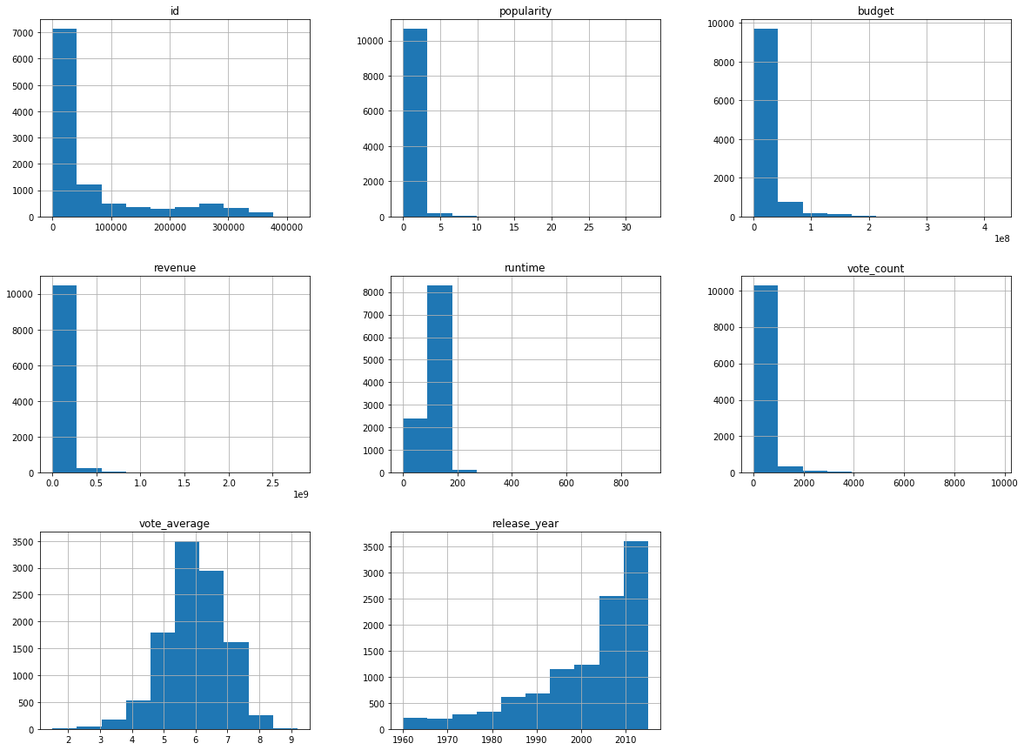

```python
tmdb.hist(figsize=(20,15));
```

### Question 1 : which year has made the biggest revenue of movies ?

```python
# using groupby and then summtion we can see the result

revenue_by_year = ((tmdb.groupby('release_year').revenue.sum())/10e7)
# diveded by 10e8 to save memory

revenue_by_year
```

```
release_year
1960     23.759765
1961     22.117362
1962     22.680736
1963     25.968542
1964     33.751030
1965     31.352476
1966     37.435299
1967     30.580450
1968     26.741822
1969     25.641674
1970     30.589100
1971     40.637038
1972     31.718959
1973     46.150577
```

[output cut: 43 more lines]

#### Drawing the revenue as a pie chart

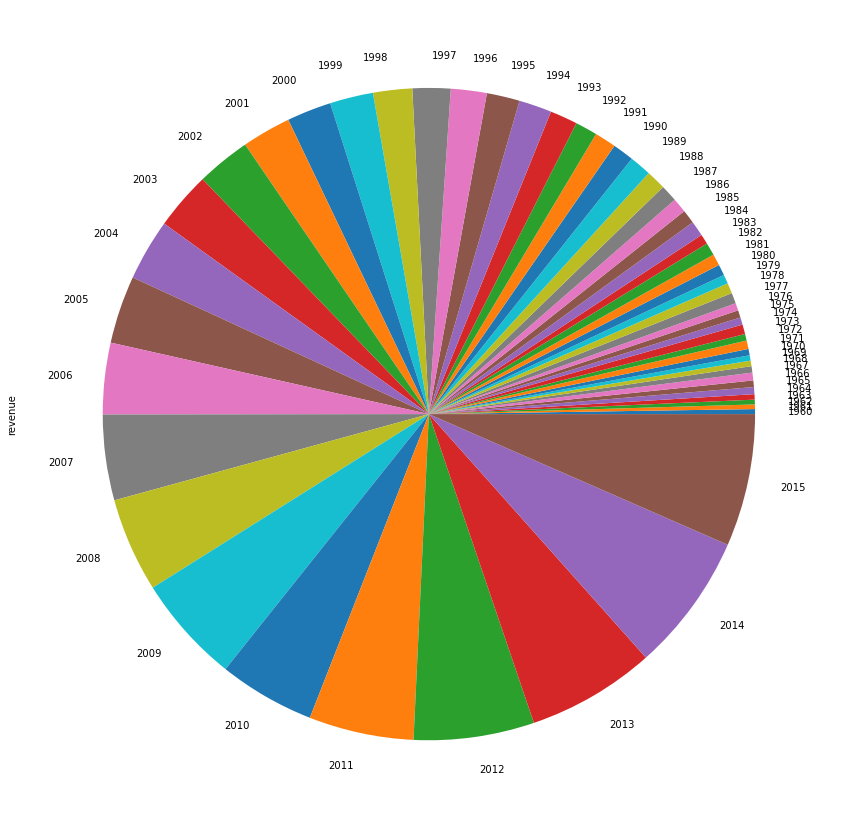

```python
revenue_by_year.plot.pie(figsize=(22,15));
```

#### another plot using bar chart for better observation

[figure not shown]

```python
plt.figure(figsize=(20, 30))
sns.barplot(y = revenue_by_year.index, x= revenue_by_year.values, palette='Accent', orient = 'h')
plt.xlabel(xlabel='release year',fontsize=15)
plt.ylabel(ylabel='revenue by hunderd milloins',fontsize=15)
plt.title(label='revenue by release year',fontsize=18);
```

seems like the year `2014` had the most revenue for the movies and was the best year for movie production, but also as we can notice the revenue of the movies started to increased exponentially after the year **1992** with a noticed increasing in **2009** and **2014**

### Question 2 : Which year had the most budget from year to year ?

```python
# using groupby and then summtion we can see the result

budget_by_year = ((tmdb.groupby('release_year').budget.sum())/10e7)
# diveded by 10e8 to save memory

budget_by_year
```

```
release_year
1960      7.290672
1961      5.994494
1962      6.080345
1963      7.803417
1964      9.924100
1965      8.079549
1966     11.027004
1967      7.769229
1968      8.096888
1969      6.876602
1970      9.261959
1971     10.596634
1972      7.432895
1973     12.025551
```

[output cut: 43 more lines]

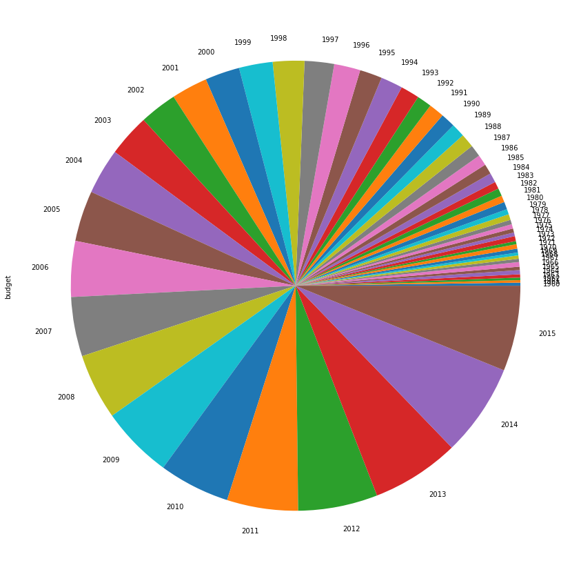

```python
budget_by_year.plot.pie(figsize=(22,15));
```

[figure not shown]

```python
plt.figure(figsize=(20, 30))
sns.barplot(y = budget_by_year.index, x= budget_by_year.values, orient = 'h')
plt.xlabel(xlabel='release year',fontsize=18)
plt.ylabel(ylabel='budget by 10 milloins',fontsize=18)
plt.title(label='budget by release year',fontsize=20);
```

from the the bar chart we notice that `2014` was also the biggest year for budget as for revenue followed by **2013** then **2015**

### Question 3 : which year had the most profit ?

by substracting the budget from the revenu we can get the **profit of the movies by the year**

```python
profit_by_year = revenue_by_year - budget_by_year
profit_by_year
```

```
release_year
1960     16.469093
1961     16.122869
1962     16.600391
1963     18.165124
1964     23.826930
1965     23.272927
1966     26.408295
1967     22.811221
1968     18.644933
1969     18.765072
1970     21.327141
1971     30.040404
1972     24.286064
1973     34.125026
```

[output cut: 43 more lines]

by Drawing a bar plot of the **Profit**

[figure not shown]

```python
plt.figure(figsize=(20, 30))
sns.barplot(y = profit_by_year.index, x= profit_by_year.values, orient = 'h')
plt.xlabel(xlabel='release year',fontsize=18)
plt.ylabel(ylabel='profit by 10 milloins',fontsize=18)
plt.title(label='profit by release year',fontsize=20);
```

from the bar chart above we can say that the year with the highest profit is also `2014` but it's followed by **2015** then **2013**

### Question 3 : which month has the highest revenue and which month had the highest budget ?

```python
months = ['January', 'February', 'March', 'April', 'May', 'June', 'July',
              'August', 'September', 'October', 'November', 'December']
revenue_by_mounth = (tmdb.groupby(tmdb['month']).revenue.sum())/10e6
revenue_by_mounth
# revenue by millions
```

```
month
01     6802.885515
02     5263.368551
03     7164.167227
04     6672.922481
05     8963.072479
06     9887.318930
07     8241.635184
08     6893.709109
09     9016.193628
10     9155.319420
11     8623.222092
12    10274.205370
Name: revenue, dtype: float64
```

```python
budget_by_mounth = (tmdb.groupby(tmdb['month']).budget.sum())/10e6
budget_by_mounth
# budget by millions
```

```
month
01    2356.670312
02    1996.100518
03    2535.447198
04    2340.663412
05    2852.320670
06    3063.648765
07    2725.387476
08    2600.395234
09    3441.404192
10    3278.853719
11    2856.973865
12    3350.683909
Name: budget, dtype: float64
```

[figure not shown]

```python
# i used this blog as a refrence https://www.weirdgeek.com/2018/11/plotting-multiple-bar-graph/
plt.figure(figsize=(20, 10))
x = np.arange(12)
ax1 = plt.subplot(1,1,1)
w = 0.3

plt.xticks(x + w /2, months , rotation='vertical',fontsize=15)
plt.yticks(fontsize=15)
revenue =ax1.bar(x, revenue_by_mounth.values , width=w, color='b', align='center')

budget =ax1.bar(x + w, budget_by_mounth.values, width=w,color='g',align='center')

plt.ylabel('revenue and Budget in millions',fontsize=18)
plt.legend([revenue, budget],['Revenue in Millions', 'budget in Millions'],fontsize=18);
```

in the above plot we can see the huge diffrence between the revenue and the budget of making movies in each month which leads to belive that the industry of movies is very profitable

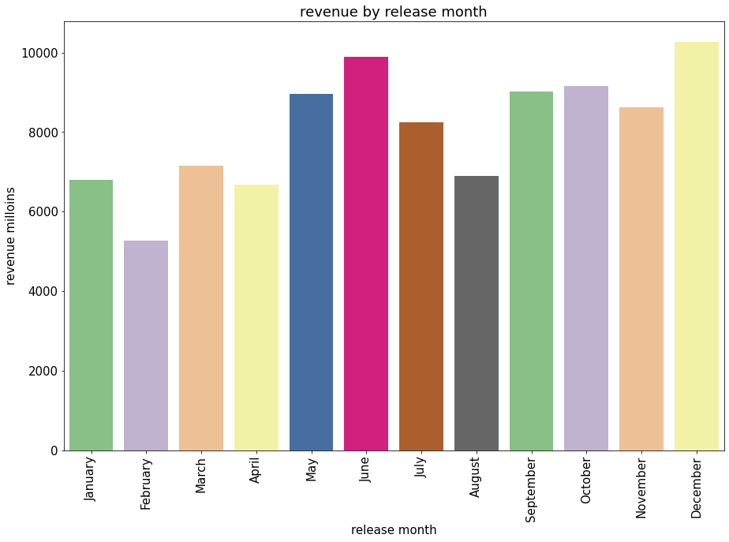

```python
plt.figure(figsize=(15, 10))
sns.barplot(x = months , y= revenue_by_mounth.values, palette='Accent')
plt.xticks(rotation='vertical',fontsize=15)
plt.yticks(fontsize=15)
plt.xlabel(xlabel='release month',fontsize=15)
plt.ylabel(ylabel='revenue milloins',fontsize=15)
plt.title(label='revenue by release month',fontsize=18);
```

Looks like the highest revenue is within **December** followed by the revenue in **June** and then **October** and it seems that there's a colleration between those months and the revenue

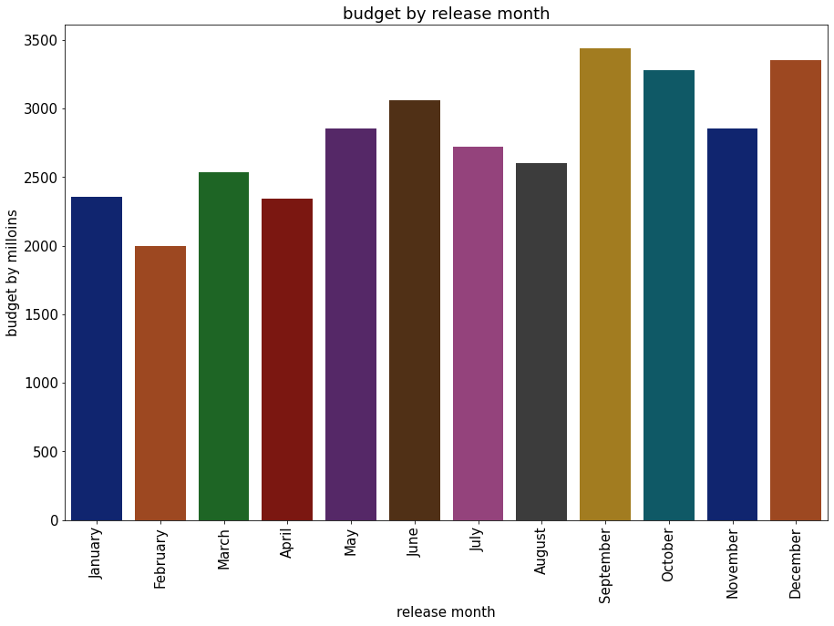

```python
plt.figure(figsize=(15, 10))
sns.barplot(x = months, y= budget_by_mounth.values, palette='dark')
plt.xticks(rotation='vertical',fontsize=15)
plt.yticks(fontsize=15)
plt.xlabel(xlabel='release month',fontsize=15)
plt.ylabel(ylabel='budget by milloins',fontsize=15)
plt.title(label='budget by release month',fontsize=18);
```

### Question 4 : Which month has the highest number of movie releases ?

```python
# first we groub the movies by it's month of release and theb we count them
number_of_movies_by_month = tmdb.groupby(tmdb['month']).id.count()
number_of_movies_by_month
```

```
month
01     919
02     691
03     822
04     797
05     809
06     827
07     799
08     918
09    1331
10    1153
11     814
12     985
Name: id, dtype: int64
```

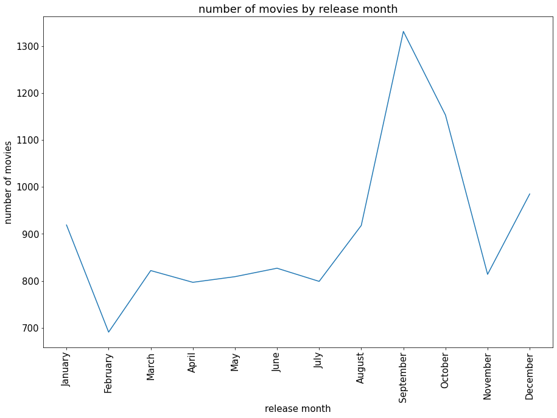

```python
# then we draw the plot
plt.figure(figsize=(15, 10))
sns.lineplot(x= months,y= number_of_movies_by_month.values)
plt.xticks(rotation='vertical',fontsize=15)
plt.yticks(fontsize=15)
plt.xlabel(xlabel='release month',fontsize=15)
plt.ylabel(ylabel='number of movies',fontsize=15)
plt.title(label='number of movies by release month',fontsize=18);
```

### Question 5 : Is there a correlation between any of the data of Tmdb dataset ?

```python
tmdb.info()
```

```
<class 'pandas.core.frame.DataFrame'>
Int64Index: 10865 entries, 0 to 10865
Data columns (total 12 columns):
 #   Column                Non-Null Count  Dtype
---  ------                --------------  -----
 0   id                    10865 non-null  int64
 1   popularity            10865 non-null  float64
 2   budget                10865 non-null  float64
 3   revenue               10865 non-null  float64
 4   original_title        10865 non-null  object
 5   runtime               10865 non-null  int64
 6   genres                10842 non-null  object
 7   production_companies  9835 non-null   object
 8   vote_count            10865 non-null  int64
 9   vote_average          10865 non-null  float64
 10  release_year          10865 non-null  int64
 11  month                 10865 non-null  object
dtypes: float64(4), int64(4), object(4)
memory usage: 933.7+ KB
```

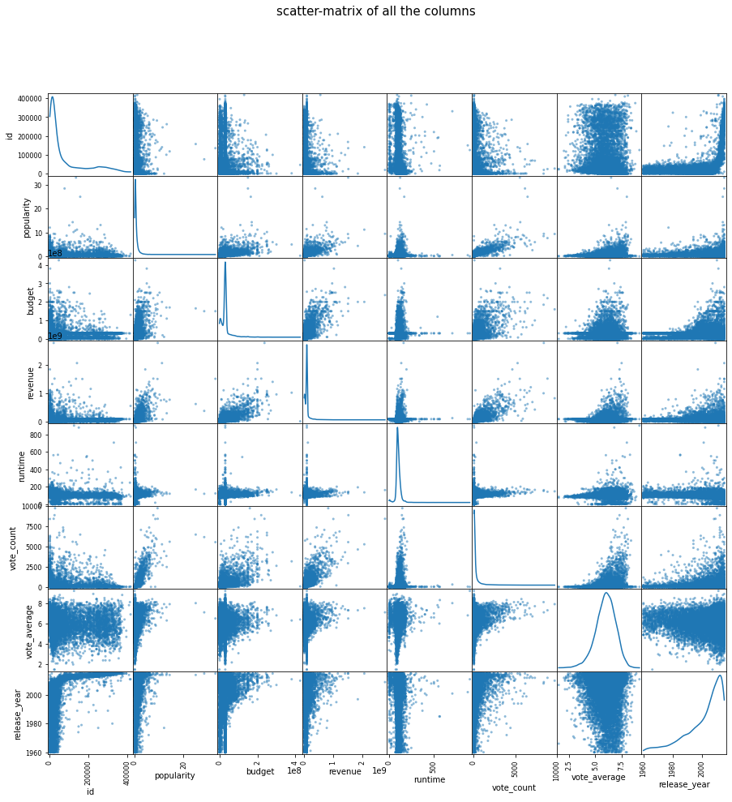

```python
pd.plotting.scatter_matrix(tmdb,figsize=(15, 15),diagonal='kde');
plt.suptitle('scatter-matrix of all the columns', fontsize=15)
```

#### From this scatter plot we can obsereve

> 1- it seems that there's a correlation `popularity` and `revenue` also there's a coleration between `popularity` and `Vote_count` let's foucs on those collerations first

> 2- also there's a correlation between `release_year` and `budget` we'll foucs on these correlation too

First let's check the relation between `popularity`, `revenue` using **scatter plot**

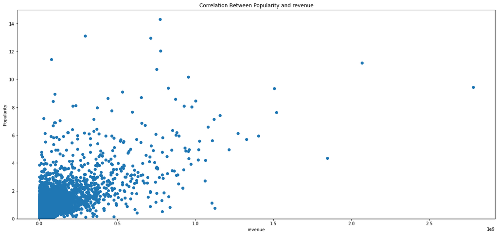

```python
plt.figure(figsize=(20,9));
plt.scatter(x= tmdb.revenue, y = tmdb.popularity)
plt.title("Correlation Between Popularity and revenue");
plt.xlabel("revenue");
plt.ylabel("Popularity");
plt.ylim(0, 15);
```

Looking at the scatter plot above, we can see that **popularity** is positively correlated with the **revenue**. which means if the movie is populare then its chances to have more revenue increases.

second let's check the colleration between the **popularity** and the **Vote_count**

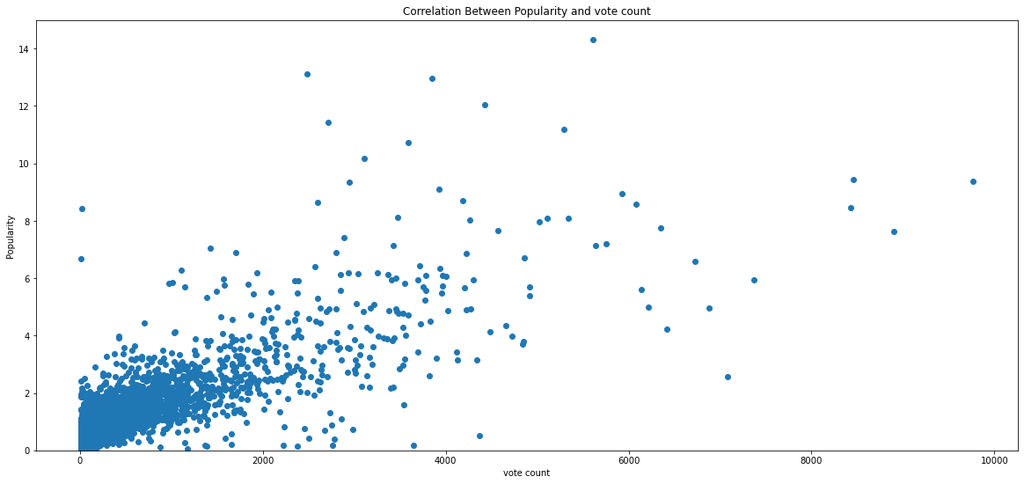

```python
plt.figure(figsize=(20,9));
plt.scatter(x= tmdb.vote_count, y = tmdb.popularity)
plt.title("Correlation Between Popularity and vote count");
plt.xlabel("vote count");
plt.ylabel("Popularity");
plt.ylim(0, 15);
```

as noticed there'a a postive colleration between the **Popularity** and the **view_count**, so does the vote_count effets the Popularity or does the Popularity and the public obinion effects the vote count ? need further investigation

**Second** let's foucs on the collereation between the `release_year` and `budget` using also scatter plot

[figure not shown]

```python
plt.figure(figsize=(20,9));
plt.scatter(x= tmdb.release_year, y = tmdb.budget)
plt.title("Correlation Between Popularity and vote count");
plt.xlabel("release year");
plt.ylabel("budget");
```

from the plot it's noticed that the budget of the movies increases along the years